# PRÁCTICA 2B: PCA

PROFESOR: DR. LUIS GUILLERMO RUIZ VELÁZQUEZ

ESTUDIANTE: EDGAR SANTIAGO GONZALEZ MARTINEZ

# Introducción

En este ejercicio analizamos la estructura del conjunto **Digits** aplicando **PCA** para reducir a **dos componentes principales** y así visualizar los datos en un plano 2D. Primero graficamos los puntos coloreándolos por su **clase real** para observar la separabilidad tras la proyección. Luego entrenamos **K-means** con **k = n_class** sobre ese mismo espacio 2D para obtener **clusters** sin usar etiquetas y volvimos a graficar, ahora coloreando por **cluster** y mostrando los **centroides**. Repetimos el flujo para **n_class de 2 a 10**, comparando en cada caso la vista por clase vs. la vista por cluster; además, calculamos una **accuracy mapeada** y el **Adjusted Rand Index (ARI)** para cuantificar la concordancia entre particiones.

# PCA para preprocesar datos

El algoritmo PCA tiene la particularidad de que sus proyecciones tienden a separar los datos cuando se aplican a bajas dimensiones. En este notebook se verá ese efecto.

En este flujo de trabajo, `import numpy as np` incorpora **NumPy** con el alias `np`, la biblioteca base para manejar **arreglos n-dimensionales** y operaciones vectorizadas/lineales que algoritmos de ML requieren; `import matplotlib.pyplot as plt` añade la interfaz **pyplot** de **Matplotlib** para **visualizar** datos y resultados; `from sklearn.cluster import KMeans` trae la clase **KMeans**, algoritmo **no supervisado** que particiona datos en *k* grupos minimizando la distancia a sus **centroides**; `from sklearn import decomposition` habilita el módulo de **reducción de dimensionalidad** de scikit-learn, del cual se usa típicamente `decomposition.PCA` para proyectar datos de alta dimensión a componentes que explican la mayor **varianza**; y `from sklearn import datasets` permite **cargar conjuntos de datos** de ejemplo (como `load_digits`, con imágenes 8×8 y etiquetas), útiles para experimentar rápidamente sin preparar fuentes externas.

```python
import numpy as np
import matplotlib.pyplot as plt

from sklearn.cluster import KMeans
from sklearn import decomposition
from sklearn import datasets
```

## Leer datos

Se lee el conjunto de datos, `load_digits` son imágenes de números escritos a mano. El parámetro `n_class` indica el número de clases que queremos, en este caso sólo la clase de 0 y 1.

En esta parte se realiza cuatro pasos: primero, `digits = datasets.load_digits(n_class=2)` carga el conjunto **Digits** de scikit-learn limitado a **2 clases**, proporcionando imágenes y sus etiquetas; luego, `X = digits.images.reshape((len(digits.images), -1))` **aplana** cada imagen a un vector de **64** características para formar la matriz de diseño `X` con forma `(n_muestras, 64)`; después, `y = digits.target` extrae el vector de **etiquetas** correspondiente a cada imagen; finalmente, `X.shape, y.shape` devuelve las **dimensiones** de ambos arreglos, y el resultado `((360, 64), (360,))` significa que hay **360 imágenes** representadas por 64 rasgos cada una y **360 etiquetas** asociadas, una por imagen.

```python
digits = datasets.load_digits(n_class=2)
X = digits.images.reshape((len(digits.images),-1))
y = digits.target
X.shape, y.shape
```

```
((360, 64), (360,))
```

Mostramos las primeras 20 imágenes, todas son en escala de grises y tienen una resolución de 8x8. La variable y contiene el número que hay en la imagen correspondiente.

El siguiente código crea una cuadrícula de **20 subgráficos** para mostrar las primeras imágenes del dataset y ponerle: `fig = plt.figure(figsize=(8, 8))` abre una figura de 8×8 pulgadas; `columns = 4` y `rows = 5` definen **5 filas × 4 columnas**. El `for i in range(20)` recorre los 20 primeros ejemplos; en cada iteración toma la imagen `8×8` con `img = digits.images[i]`, crea el subgráfico correspondiente con `fig.add_subplot(rows, columns, i + 1)`, dibuja la imagen con `plt.imshow(img)`, oculta los ejes con `plt.axis('off')` y coloca como título la **clase** con `plt.title(y[i])`. Finalmente, `plt.show()` imprime la cuadrícula.

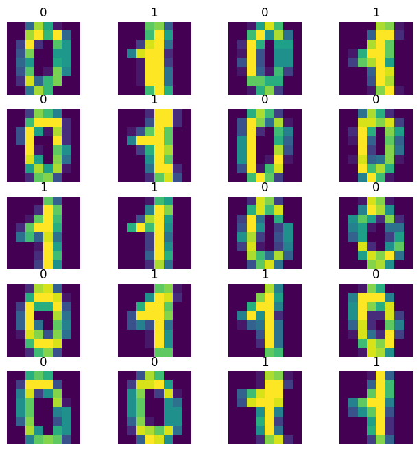

```python
fig=plt.figure(figsize=(8, 8))
columns = 4
rows = 5
for i in range(20):
    img = digits.images[i]
    fig.add_subplot(rows, columns, i + 1)
    plt.imshow(img)
    plt.axis('off')
    plt.title(y[i])
plt.show()
```

## Aplicar PCA y graficar en dos dimensiones.

Aplicar PCA para reducir la dimensión a dos y graficar los puntos, el color de los puntos debe indicar la clase a la que pertenece.

En esta parte utilizamos **PCA** para reducir los vectores de píxeles (64 rasgos por imagen) a **dos componentes principales** y visualizarlos en un plano 2D, coloreando cada punto según su **clase real**. Primero, `PCA(n_components=2, random_state=0)` y ajusta `X` con `fit_transform`, generando `X_2d` de forma `(n_muestras, 2)`. A continuación, imprime la **forma original** y la **reducida**, junto con el **porcentaje de varianza explicada** por cada componente (`explained_variance_ratio_`). Para la gráfica, crea una figura y, para cada clase en `y`, traza un **dispersograma** con puntos de esa clase y una **leyenda** clara. Etiqueta los ejes con el **porcentaje de varianza** de PC1 y PC2, añade un **título**, activa una **cuadrícula suave**, ajusta el diseño con `tight_layout()` y muestra la figura con `plt.show()`. Así, el lector puede evaluar visualmente si las clases forman grupos distinguibles en la proyección de máxima varianza capturada por PCA.

Con respecto a los reusltados, en la figura se observa las imágenes de dígitos en dos componentes principales que explican en conjunto **59.3%** de la variabilidad (PC1 = **43.0%**, PC2 = **16.3%**). Se observa que la **separación entre clases ocurre principalmente a lo largo de PC1**: la *Clase 0* se concentra a la izquierda (valores negativos de PC1) formando un grupo **compacto**, mientras que la *Clase 1* aparece a la derecha (valores positivos de PC1) con una **dispersión mayor**.

Por su parte, **PC2** parece capturar **variación intra-clase**, sobre todo dentro de la *Clase 1*, donde se aprecian subestructuras y una forma curva; la *Clase 0* permanece más homogénea alrededor de PC2 ≈ 0. Se identifican **pocos atípicos** cercanos a la frontera entre grupos (PC1 próximo a 0). En general, la proyección revela **alta separabilidad**.

```
Forma original: (360, 64)
Forma reducida: (360, 2)
Varianza explicada (%): [43.04 16.27]
```

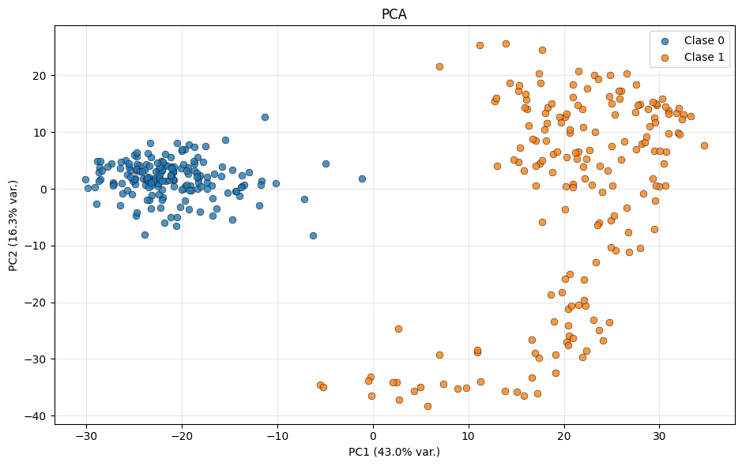

```python
# PCA a 2 componentes y transformar X
pca = PCA(n_components=2, random_state=0)
X_2d = pca.fit_transform(X)

# 2) Comprobaciones rápidas
print("Forma original:", X.shape)
print("Forma reducida:", X_2d.shape)
print("Varianza explicada (%):", np.round(pca.explained_variance_ratio_ * 100, 2))

# Graficar
plt.figure(figsize=(9.5,6))

# Scatter por clase para tener leyenda clara
clases = np.unique(y)
for c in clases:
    idx = (y == c)
    plt.scatter(
        X_2d[idx, 0], X_2d[idx, 1],
        s=40, alpha=0.8, edgecolor='k', linewidth=0.4,
        label=f"Clase {c}"
    )

# % de varianza explicada
pc1_var = pca.explained_variance_ratio_[0] * 100
pc2_var = pca.explained_variance_ratio_[1] * 100
plt.xlabel(f"PC1 ({pc1_var:.1f}% var.)")
plt.ylabel(f"PC2 ({pc2_var:.1f}% var.)")
plt.title("PCA")
plt.legend()
plt.grid(True, alpha=0.3)
plt.tight_layout()
plt.show()
```

Ahora que los puntos se encuentran separados, aplicar kmeans para separar los dos clusters.

Ahora bien, el parámetro `n_clusters=2` fija el número de clústeres; `n_init=10` indica que el algoritmo probará **10 inicializaciones** distintas (k-means++) y conservará la mejor según la **suma de distancias cuadráticas intra-clúster**; `random_state=0` hace el resultado **reproducible**. Con `klabels = kmeans.fit_predict(X_2d)` se **ajusta** el modelo y se **asigna** a cada observación una etiqueta de clúster (**0** o **1**); estas etiquetas son **arbitrarias** y la asignación se basa en la **distancia euclidiana** a los centroides. Luego, `centros = kmeans.cluster_centers_` recupera las coordenadas de los **centroides** en el plano PCA. Finalmente, `print("Centroides (PC1, PC2):\n", centros)` muestra las coordenadas de cada centroide, útiles para inferir la **frontera de decisión**.

Los centroides estimados por K-means quedan en puntos casi simétricos respecto al origen: (20.97,-1.35) y (-20.97,1.35). Esto indica que la separación entre grupos está dominada por **PC1**: un centroide agrupa observaciones con PC1 positivo y el otro con PC1 negativo, mientras que las diferencias en **PC2** son pequeñas.

```python
# KMeans con 2 clusters sobre las coordenadas PCA
kmeans = KMeans(n_clusters=2, n_init=10, random_state=0)
klabels = kmeans.fit_predict(X_2d)
centros = kmeans.cluster_centers_

print("Centroides (PC1, PC2):\n", centros)
```

```
Centroides (PC1, PC2):
 [[ 20.9692236   -1.34790884]
 [-20.9692236    1.34790884]]
```

La figura muestra el resultado de aplicar **K-means (k=2)** sobre la proyección **PCA a 2D**. Los **centroides** quedan casi **simétricos** respecto al origen y separados principalmente a lo largo de **PC1**, lo que indica que la partición de K-means está dominada por esa componente. El **clúster izquierdo** es **compacto y homogéneo** alrededor de valores negativos de PC1, mientras que el **clúster derecho** presenta **mayor dispersión** y una forma **curvilínea**, sugiriendo variación interna capturada por **PC2**.

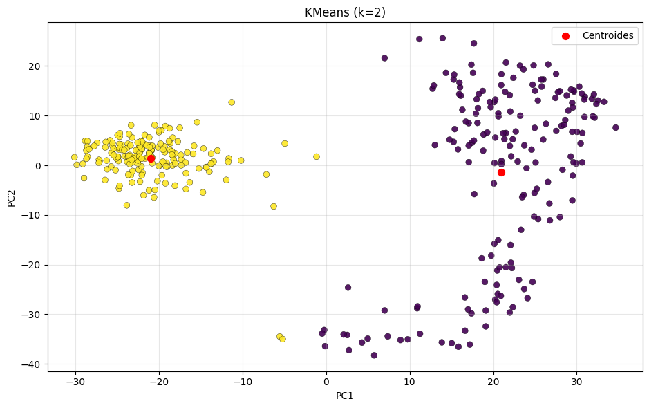

```python
plt.figure(figsize=(9.5,6))
plt.scatter(X_2d[:,0], X_2d[:,1], c=klabels, s=40, alpha=0.9, edgecolor='k', linewidth=0.3)
plt.scatter(centros[:,0], centros[:,1], s=50, marker='o', c='red', label='Centroides')
plt.xlabel("PC1"); plt.ylabel("PC2")
plt.title("KMeans (k=2)")
plt.legend()
plt.grid(True, alpha=0.3)
plt.tight_layout()
plt.show()
```

Graficar otra vez los puntos en dos dimensiones pero donde el color de los puntos indique la pertenencia a uno de los clusters. Comparar con la imagen anterior.

Volvemos a graficar las proyecciones **PCA (2D)**, pero ahora el **color** de cada punto proviene de la **etiqueta de K-means** (`klabels`). Primero, recupera los porcentajes de **varianza explicada** por PC1 y PC2 para rotular los ejes. Luego crea una figura y, para cada valor distinto en `klabels`, dibuja un **scatter** de los puntos que pertenecen a ese clúster, con tamaño (`s`), transparencia (`alpha`) y borde (`edgecolor`) definidos, y con una **leyenda** identificando “Cluster 0/1”.

Al comparar esta figura con la anterior (color = **clase real**), se espera observar una **correspondencia alta**: un clúster ocupa mayormente la región de **PC1 negativo** y el otro la de **PC1 positivo**, lo que confirma que la **separación principal** ocurre a lo largo de PC1. La **proximidad** de los centroides a los centros de masa de cada nube y su **alineación** casi simétrica respecto al eje vertical refuerzan que la frontera de decisión implícita es **casi vertical** (PC1 ≈ 0). Las **diferencias** entre ambas vistas suelen concentrarse en observaciones **cercanas a la frontera**, donde la distancia a ambos centroides es similar.

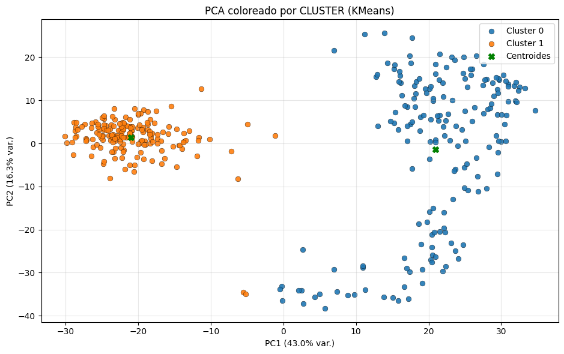

```python
# % varianza por claridad
pc1_var = pca.explained_variance_ratio_[0]*100
pc2_var = pca.explained_variance_ratio_[1]*100

plt.figure(figsize=(9.5,6))
for cl in np.unique(klabels):
    idx = (klabels == cl)
    plt.scatter(X_2d[idx, 0], X_2d[idx, 1],
                s=40, alpha=0.9, edgecolor='k', linewidth=0.3,
                label=f"Cluster {cl}")

# Centroides
plt.scatter(centros[:, 0], centros[:, 1],
            s=50, marker='X', c='green', label='Centroides')

plt.xlabel(f"PC1 ({pc1_var:.1f}% var.)")
plt.ylabel(f"PC2 ({pc2_var:.1f}% var.)")
plt.title("PCA coloreado por CLUSTER (KMeans)")
plt.legend(); plt.grid(True, alpha=0.3); plt.tight_layout(); plt.show()
```

Hacer lo mismo pero dentro de un ciclo `for` donde el número de clases vaya de 2 a 10 (variar el parámetro `n_class` al leer el dataset). Comparar las imágenes conforme se van agregando más clases.

El bucle recorre `n_class = 2…10`. En cada iteración, carga el subconjunto de **Digits** con ese número de clases, aplana las imágenes y aplica **PCA** con `n_components=2` para proyectar los datos a un plano 2D. Con esas coordenadas (`X_2d`) ajusta **KMeans** con `k = n_class` y obtiene tanto las **etiquetas de clúster** (`klabels`) como los **centroides**. Después evalúa el ajuste mapeando cada clúster a su **clase mayoritaria** y calcula **Accuracy** (con mapeo) y **ARI** (sin mapeo). Finalmente, imprime dos graficos comparables: a la izquierda colorea por **clase real** y a la derecha por **clúster**.

Con **pocas clases**, los grupos en PCA suelen verse **bien separados** y KMeans alcanza **alta concordancia** (Accuracy/ARI altos). A medida que **aumenta** `n_class`, PC1+PC2 capturan una **menor fracción** de la variabilidad y las nubes tienden a **solaparse**, por lo que la concordancia entre **clases** y **clústeres** se **reduce**.

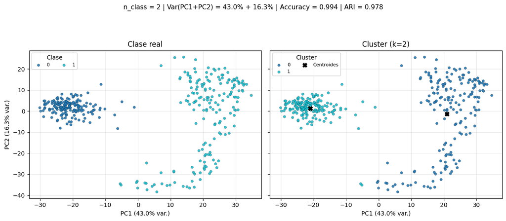

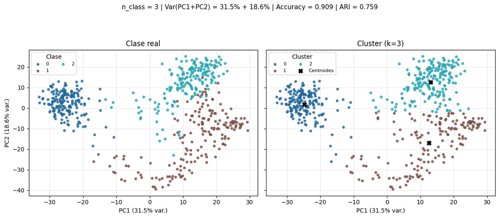

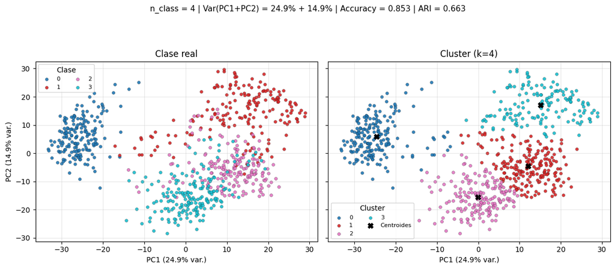

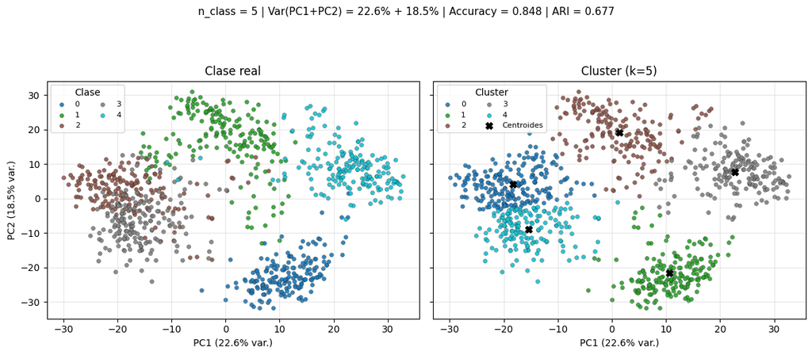

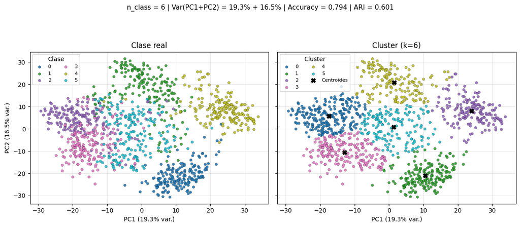

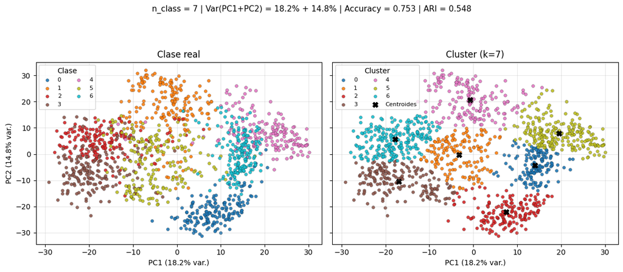

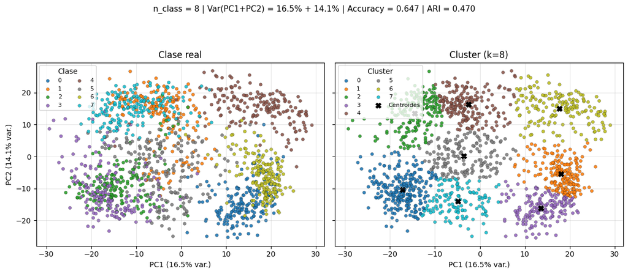

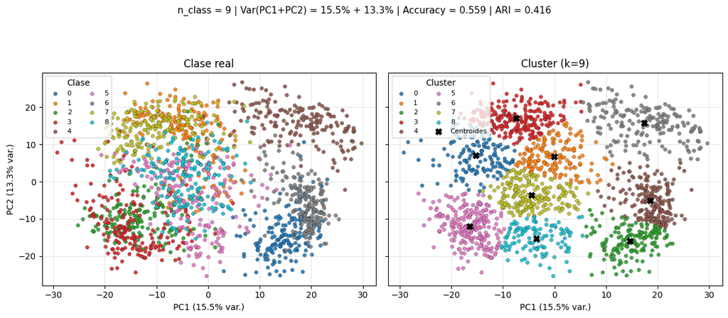

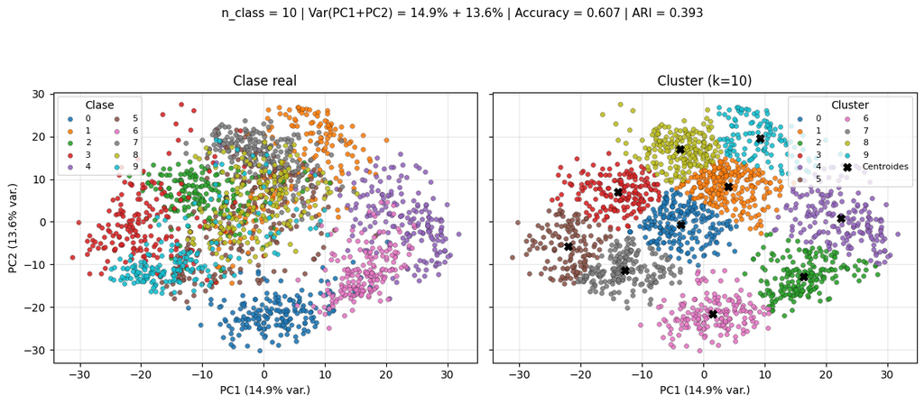

```python
import numpy as np
import matplotlib as mpl
import matplotlib.pyplot as plt
from sklearn import datasets
from sklearn.decomposition import PCA
from sklearn.cluster import KMeans
from sklearn.metrics import accuracy_score, adjusted_rand_score

RSEED = 0

for num_clusters in range(2, 11):
    # Cargar dataset con 'num_clusters' clases
    digits = datasets.load_digits(n_class=num_clusters)
    X = digits.images.reshape(len(digits.images), -1)
    y = digits.target

    # PCA a 2D
    pca = PCA(n_components=2, random_state=RSEED)
    X_2d = pca.fit_transform(X)
    pc1_var, pc2_var = pca.explained_variance_ratio_ * 100

    # KMeans con k = num_clusters
    kmeans = KMeans(n_clusters=num_clusters, n_init=10, random_state=RSEED)
    klabels = kmeans.fit_predict(X_2d)
    centros = kmeans.cluster_centers_

    # Evaluación rápida (opcional)
    mapping = {}
    for cl in np.unique(klabels):
        idx = (klabels == cl)
        vals, counts = np.unique(y[idx], return_counts=True)
        mapping[cl] = vals[np.argmax(counts)]
    y_pred = np.array([mapping[cl] for cl in klabels])
    acc = accuracy_score(y, y_pred)
    ari = adjusted_rand_score(y, klabels)

    # Gráfica comparativa
    fig, axes = plt.subplots(1, 2, figsize=(12, 5), sharex=True, sharey=True)
    cmap = mpl.colormaps['tab10'].resampled(num_clusters)

    # Color_izquierda = clase real
    for c in np.unique(y):
        idx = (y == c)
        axes[0].scatter(X_2d[idx,0], X_2d[idx,1], s=18, alpha=0.9,
                        edgecolor='k', linewidth=0.2, color=cmap(c), label=str(c))
    axes[0].set_title("Clase real")
    axes[0].set_xlabel(f"PC1 ({pc1_var:.1f}% var.)")
    axes[0].set_ylabel(f"PC2 ({pc2_var:.1f}% var.)")
    axes[0].legend(title="Clase", ncol=2, fontsize=8)
    axes[0].grid(True, alpha=0.3)

    # Color_derecha = cluster (KMeans)
    for cl in np.unique(klabels):
        idx = (klabels == cl)
        axes[1].scatter(X_2d[idx,0], X_2d[idx,1], s=18, alpha=0.9,
                        edgecolor='k', linewidth=0.2, color=cmap(cl), label=str(cl))
    axes[1].scatter(centros[:,0], centros[:,1], s=50, marker='X', c='black', label='Centroides')
    axes[1].set_title(f"Cluster (k={num_clusters})")
    axes[1].set_xlabel(f"PC1 ({pc1_var:.1f}% var.)")
    axes[1].legend(title="Cluster", ncol=2, fontsize=8)
    axes[1].grid(True, alpha=0.3)

    fig.suptitle(
        f"n_class = {num_clusters} | Var(PC1+PC2) = {pc1_var:.1f}% + {pc2_var:.1f}% | "
        f"Accuracy = {acc:.3f} | ARI = {ari:.3f}",
        y=1.03, fontsize=11
    )
    fig.tight_layout(rect=[0, 0, 1, 0.95])
    plt.show()
```

# Conclusión

Con **pocas clases (2–3)**, la proyección PCA suele mostrar **regiones más distinguibles**, por lo que K-means se alinea razonablemente con las etiquetas (accuracy/ARI relativamente altos). A medida que **aumentan las clases (≥4)**, las nubes se **solapan** con mayor frecuencia en 2D y la concordancia entre **clase** y **cluster** disminuye, lo cual es esperable porque PCA **no es supervisado** (maximiza varianza, no separabilidad) y los **labels de K-means** son arbitrarios.

**Documento en Colab** [enlace](https://colab.research.google.com/drive/1cW82NryJxvTXf6sXYLTapjPD6WtCP7ij?usp=sharing).

- Bishop, C. M., & Nasrabadi, N. M. (2006). *Pattern recognition and machine learning* (Vol. 4, No. 4, p. 738). New York: Springer.
- Géron, A. (2022). *Hands-On Machine Learning with Scikit-Learn, Keras, and TensorFlow*. O’Reilly Media.
- Hastie, T., Tibshirani, R., & Friedman, J. (2009). *The Elements of Statistical Learning*. Springer.
- Jolliffe, I. (2011). Principal component analysis. In *International Encyclopedia of Statistical Science* (pp. 1094–1096). Springer, Berlin, Heidelberg.
- Maaten, L. V. D., & Hinton, G. (2008). Visualizing data using t-SNE. *Journal of Machine Learning Research, 9*(Nov), 2579–2605.
- McInnes, L., Healy, J., & Melville, J. (2018). UMAP: Uniform manifold approximation and projection for dimension reduction. *arXiv preprint* arXiv:1802.03426.
- McKinney, W. (2022). *Python for Data Analysis* (3rd ed.). O’Reilly.
- Pedregosa, F., Varoquaux, G., Gramfort, A., et al. (2011). Scikit-learn: Machine learning in Python. *Journal of Machine Learning Research, 12*, 2825–2830.
- Raschka, S., & Mirjalili, V. (2019). *Python Machine Learning* (3rd ed.). Packt.
- Scikit-learn User Guide — secciones Decomposition → PCA, Clustering → KMeans y Metrics (ARI, silhouette, etc.). https://scikit-learn.org/stable/